# Synthetic Canadians: Cross-Dataset Comparison

Synthetic Survey Data Quality Across Five Canadian Political Surveys

Author

Synthetic Opinion Lab

Published

March 16, 2026

## Overview

This report compares synthetic data quality across **five Canadian political surveys** spanning 2019–2021. Three generators are evaluated on each dataset: a **Large Language Model** (Qwen2.5-7B-Instruct via Together API), an **Item Response Theory** model (Graded Response Model), and an **Agent-based** opinion dynamics simulation.

Table 1: Overall quality scores by dataset and generator

| Dataset | Survey | Year | Type | N real | LLM score | IRT score | Agent score |
| --- | --- | --- | --- | --- | --- | --- | --- |
| DC19 | Democracy Checkup 2019 | 2019 | DC | 2,749 | 0.743 | 0.530 | 0.501 |
| DC20 | Democracy Checkup 2020 | 2020 | DC | 4,043 | 0.749 | 0.569 | 0.531 |
| DC21 | Democracy Checkup 2021 | 2021 | DC | 7,576 | 0.803 | 0.625 | 0.548 |
| CES19 | Canadian Election Study 2019 | 2019 | CES | 302 | 0.586 | 0.486 | 0.485 |
| CES21 | Canadian Election Study 2021 | 2021 | CES | 9,418 | 0.606 | 0.485 | 0.559 |

## Quality Scores by Generator

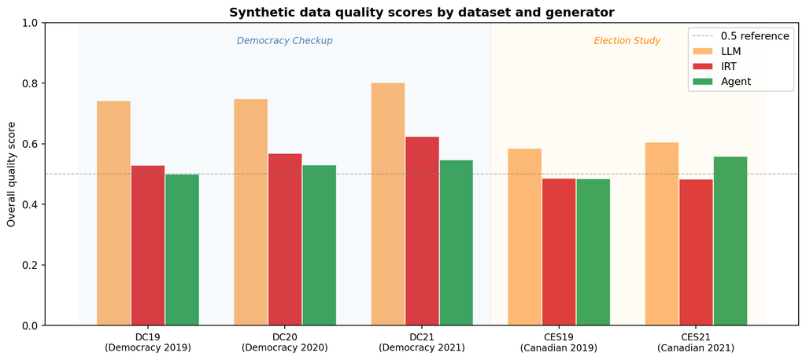

## LLM Consistently Leads

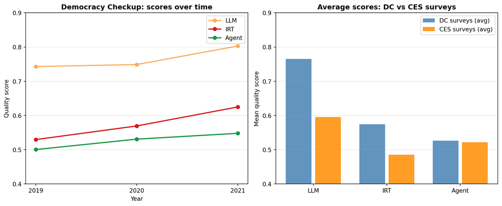

**Key observations:**

- **LLM** is the top-performing generator on every dataset without exception.
- **IRT** and **Agent** are closely matched across datasets, with IRT narrowly ahead on DC surveys and Agent slightly ahead on CES21.
- **DC surveys score higher** than CES surveys for all generators. DC surveys use uniform 4-point scales for most items, while CES mixes 4/5/8/9-point scales — wider scale variety makes distribution matching harder.
- **DC21 is the easiest dataset** (LLM = 0.803), likely due to its large sample (n = 7,576) and homogeneous scale structure.

## Score Gap: LLM vs Best Alternative

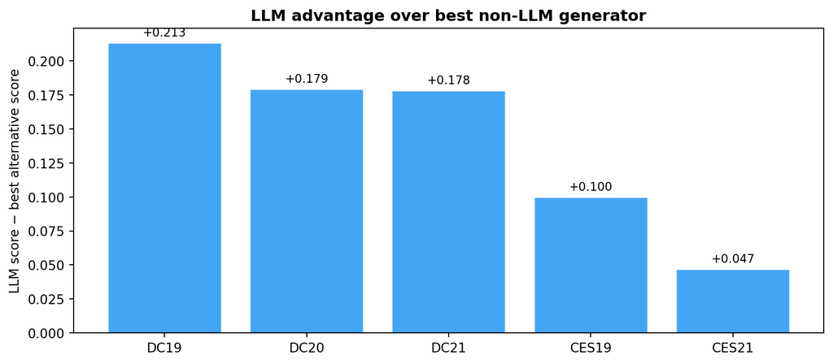

## Sample Sizes and Durations

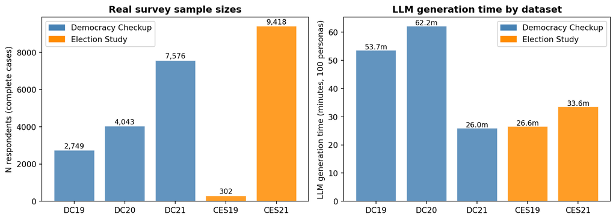

## Summary Table

| Dataset | Survey | N real | LLM | IRT | Agent | Best |
| --- | --- | --- | --- | --- | --- | --- |
| DC19 | Democracy Checkup 2019 | 2,749 | 0.743 | 0.530 | 0.501 | LLM |
| DC20 | Democracy Checkup 2020 | 4,043 | 0.749 | 0.569 | 0.531 | LLM |
| DC21 | Democracy Checkup 2021 | 7,576 | 0.803 | 0.625 | 0.548 | LLM |
| CES19 | Canadian Election Study 2019 | 302 | 0.586 | 0.486 | 0.485 | LLM |
| CES21 | Canadian Election Study 2021 | 9,418 | 0.606 | 0.485 | 0.559 | LLM |

LLM = Qwen2.5-7B-Instruct-Turbo via Together API (100 synthetic respondents) IRT = Graded Response Model (1,000 synthetic respondents) Agent = Opinion dynamics simulation, Watts-Strogatz network (500 synthetic respondents)